# 5. Statistische besluitvorming

Author

Lieven Clement

Published

Invalid Date

# 1 Introduction

## 1.1 Population

- Het doel van een wetenschappelijk onderzoek is om conclusies te trekken over de algemene populatie
- Hier bestuderen we de invloed van Captopril op de bloeddruk van patiënten met hyptertensie.
- We zullen data verzamelen en deze dan modelleren
- We moeten de onderzoeksvraag altijd vertalen naar de modelparameters of een combinatie van modelparameters.
- bv. het populatie gemiddelde
  $$E(X)=\mu$$
- Vermindert de bloeddruk bij patiënten met hypertensie gemiddeld na toedienen van Captopril?

## 1.2 Overzicht

- Experimenteel Design & Data Exploratie
- Puntschatters (Schatting)
- Interval schatters (Statistische inferentie)
- Hypothese testen (Statistische inferentie)

# 2 Captopril voorbeeld

## 2.1 Experimental design

- 15 patiënten werden at random getrokken uit de populatie van patiënten met hypertensie
- pre-test/post-test design: de systolische en diastolysche bloeddruk worden gemeten voor en na toedienen van Captopril.
- Voordeel: We kunnen het effect van de Captopril toediening op de bloeddruk van de individuele patiënten beoordelen.
- Nadeel?

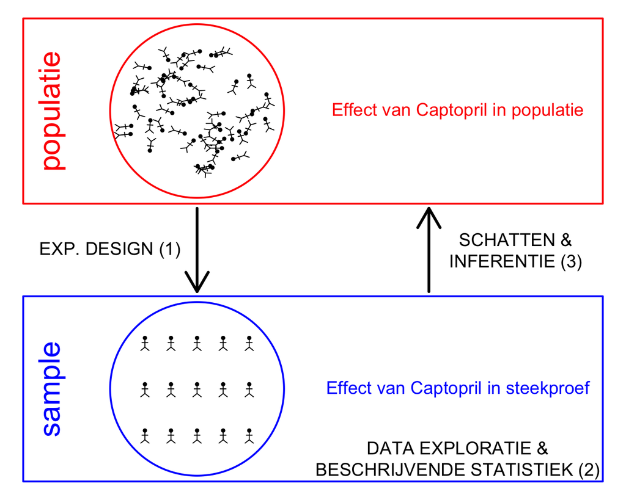

## 2.2 Data Exploratie en Beschrijvende Statistiek

```r
captopril <- read_csv("https://raw.githubusercontent.com/statOmics/sbc/master/data/captopril.txt")
head(captopril)
```

```
# A tibble: 6 × 5
     id  SBPb  DBPb  SBPa  DBPa
  <dbl> <dbl> <dbl> <dbl> <dbl>
1     1   210   130   201   125
2     2   169   122   165   121
3     3   187   124   166   121
4     4   160   104   157   106
5     5   167   112   147   101
6     6   176   101   145    85
```

```r
summary(captopril)
```

```
       id            SBPb            DBPb            SBPa          DBPa
 Min.   : 1.0   Min.   :146.0   Min.   : 98.0   Min.   :129   Min.   : 82.0
 1st Qu.: 4.5   1st Qu.:163.5   1st Qu.:103.0   1st Qu.:146   1st Qu.: 98.0
 Median : 8.0   Median :174.0   Median :112.0   Median :157   Median :103.0
 Mean   : 8.0   Mean   :176.9   Mean   :112.3   Mean   :158   Mean   :103.1
 3rd Qu.:11.5   3rd Qu.:192.5   3rd Qu.:121.5   3rd Qu.:168   3rd Qu.:108.0
 Max.   :15.0   Max.   :210.0   Max.   :130.0   Max.   :201   Max.   :125.0
```

```r
captoprilTidy <-
  captopril |>
  gather(type,bp,-id)

captoSum <- captoprilTidy |>
  group_by(type) |>
  summarize(
    mean = mean(bp,na.rm=TRUE),
    sd = sd(bp,na.rm=TRUE),
    n = sum(!is.na(bp))) |>
  mutate(se = sd/sqrt(n))

captoSum
```

```
# A tibble: 4 × 5
  type   mean    sd     n    se
  <chr> <dbl> <dbl> <int> <dbl>
1 DBPa   103.  12.6    15  3.24
2 DBPb   112.  10.5    15  2.70
3 SBPa   158   20.0    15  5.16
4 SBPb   177.  20.6    15  5.31
```

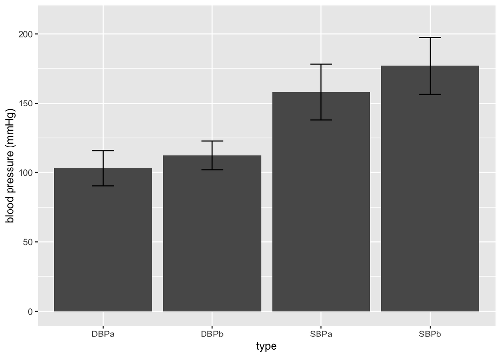

```r
captoSum |>
  ggplot(aes(x=type,y=mean)) +
  geom_bar(stat="identity") +
  geom_errorbar(aes(ymin=mean-sd, ymax=mean+sd),width=.2) +
  ylim(0,210) +
  ylab("blood pressure (mmHg)")
```

- Deze figuur is niet informatief! Het toont de ruwe data niet enkel gemiddelden en de standaard deviatie voor een bloeddruk karakteristiek.

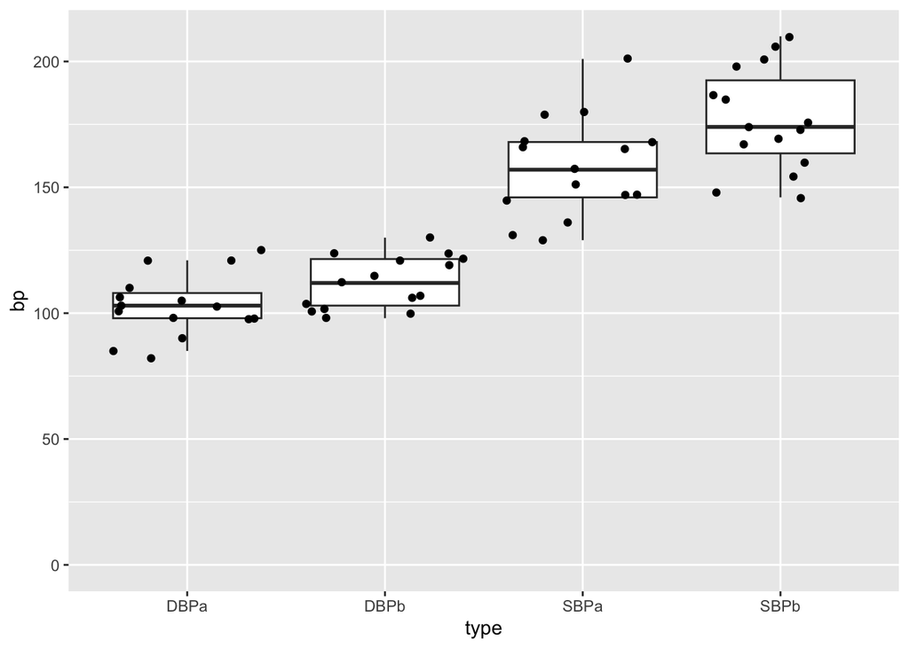

```r
captoprilTidy |>
  ggplot(aes(x=type,y=bp)) +
  geom_boxplot(outlier.shape=NA) +
  geom_point(position="jitter") +
  ylim(0,210)
```

We zien dat veel van de ruimte die werd ingenomen door de barplot geen gegevens bevat!

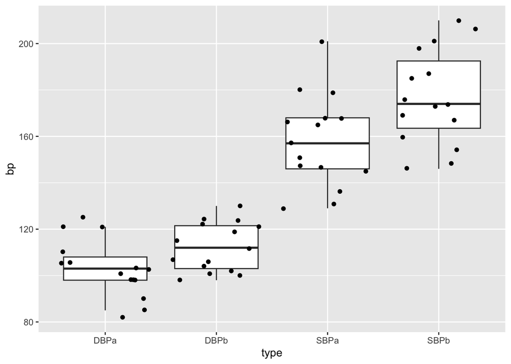

```r
captoprilTidy |>
  ggplot(aes(x=type,y=bp)) +
  geom_boxplot(outlier.shape=NA) +
  geom_point(position="jitter")
```

- Deze plot zou informatief zijn geweest als de gegevens over verschillende individuen waren verzameld.
- De bloeddruk wordt echter bij dezelfde patiënt gemeten!
- We zullen een plot maken waar we de systolische bloeddruk filteren

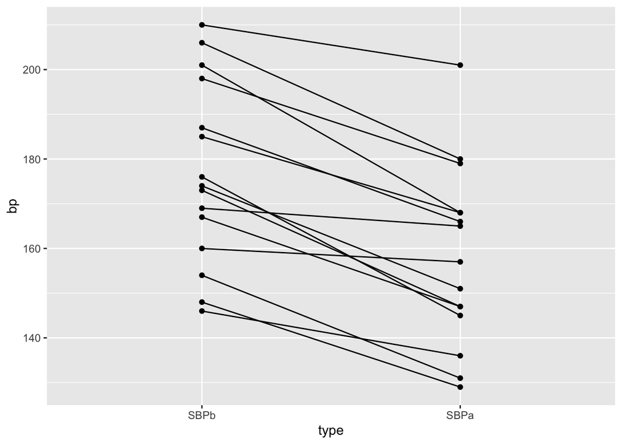

```r
captoprilTidy |>
  filter(type%in%c("SBPa","SBPb")) |>
  mutate(type=factor(type,levels=c("SBPb","SBPa"))) |>
  ggplot(aes(x=type,y=bp)) +
  geom_line(aes(group = id)) +
  geom_point()
```

- We hebben gepaarde data. We kunnen het effect van de behandeling dus onmiddellijk inschatten door de bloeddruk na behandeling te vergelijken met de bloeddruk vóór de behandeling.

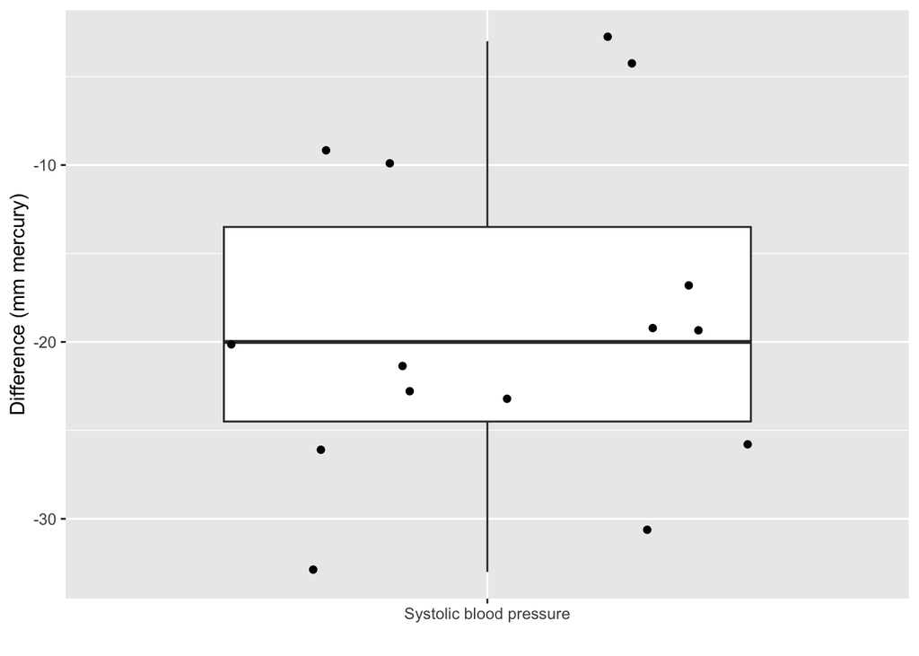

```r
captopril <-
  captopril |>
  mutate(deltaSBP = SBPa - SBPb)

captopril |>
  ggplot(aes(x="Systolic blood pressure",y=deltaSBP)) +
  geom_boxplot(outlier.shape=NA) +
  geom_point(position="jitter")+
  ylab("Difference (mm mercury)") +
  xlab("")
```

```r
captopril |>
  summarize(
    mean = mean(deltaSBP,na.rm=TRUE),
    sd = sd(deltaSBP,na.rm=TRUE),
    n = sum(!is.na(deltaSBP))) |>
  mutate(se = sd/sqrt(n))
```

```
# A tibble: 1 × 4
   mean    sd     n    se
  <dbl> <dbl> <int> <dbl>
1 -18.9  9.03    15  2.33
```

- Pre-test/post-test design: Effect van Captopril in de steekproef met $X=\Delta_\text{na-voor}$!
- Hoe modelleren we $X=\Delta_\text{na-voor}$ en schatten we het effect van Captopril?

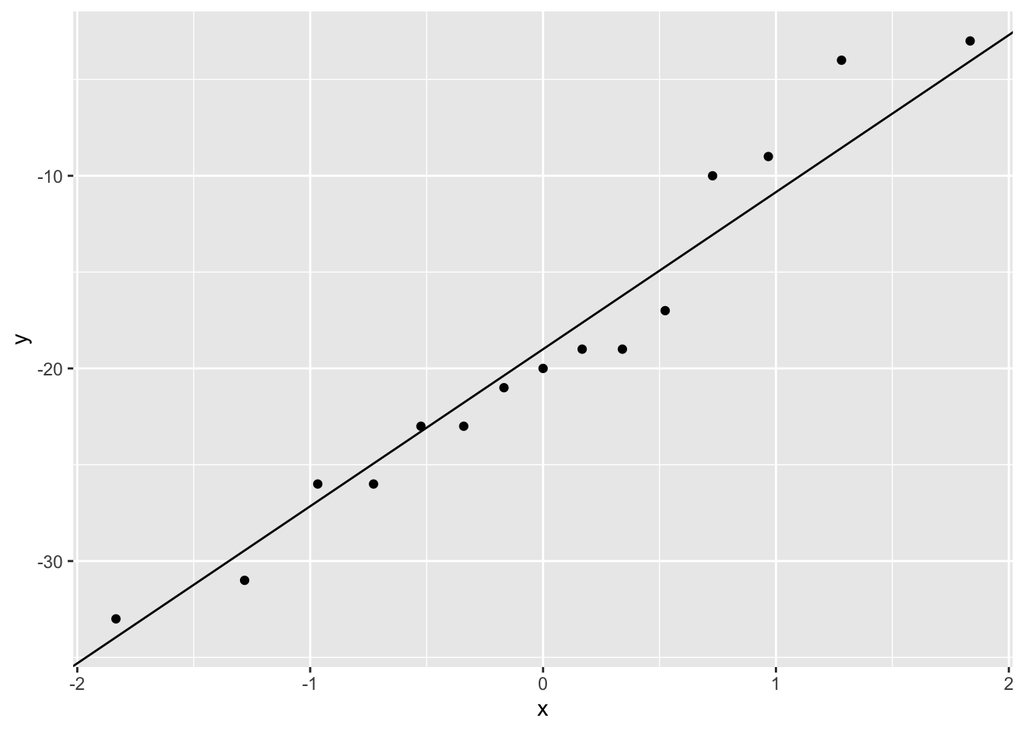

```r
captopril |>
  ggplot(aes(sample=deltaSBP)) +
  stat_qq() +
  stat_qq_line()
```

De systolische bloeddruk verschillen zijn ongeveer normaal verdeeld. ***

## 2.3 Schatten

- Geen susbtantiële afwijkingen van normaliteit.
- We kunnen aannemen dat de verschillen $X \sim N(\mu, \sigma^2)$.
- Het effect van Captopril in de populatie wordt weergegeven door het gemiddelde bloeddruk verschil $\mu$.
- De gemiddelde bloeddruk $\mu$ in de populatie kan worden geschat met behulp van het steekproefgemiddelde $\bar x$ = -18.93
- De standaarddeviatie $\sigma$ met de steekproefstandaarddeviatie $\text{S}$ = 9.03.
- Is het effect dat we in de steekproef observeren groot genoeg om te concluderen dat er een effect is van de captoprilbehandeling op de bloeddruk op populatieniveau?
- Onze schattingen zullen van steekproef tot steekproef veranderen!
- Hoe zijn de schatters $\bar X$ en $S$ verdeeld?

# 3 Punt schatters: het steekproefgemiddelde

- Stel dat $X$ een willekeurige steekproef is uit de populatie en neem aan dat $X \sim N(\mu,\sigma^2)$
- Schat $\mu$ op basis van de steekproef $X_1,...,X_n$, gebruik makende van het steekproefgemiddelde
  $$\bar X = \frac{X_1+ X_2+ ... + X_n}{n} = \frac{\sum_{i=1}^{n} X_i}{n}$$
  van willekeurige variabelen $X_1,X_2, ..., X_n$.
- Steekproef gemiddelde $\bar X$ is een willekeurige variable dat varieert van steekproef tot steekproef.
- Bestudeer de theoretische verdeling van het steekproefgemiddelde om inzicht te krijgen
  1. in hoe het steekproefgemiddelde kan variëren in een nieuw gelijkaardig onderzoek
  2. hoe ver $\bar X$ kan verschillen van het populatiegemiddelde $\mu$

## 3.1 Overzicht

1. Het steekproefgemiddelde is onvertekend
2. Precisie van steekproefgemiddelde
3. Distributie van steekproefgemiddelde

## 3.2 Het steekproefgemiddelde is onvertekend

**Klik om het bewijs te zien**

$$\begin{eqnarray*}
E(\bar X) &=& E \left(\frac{X_1+ X_2+ ... + X_n}{n}\right) \\
&= & \frac{E(X_1)+ E(X_2)+ ... + E(X_n)}{n} \\
&=& \frac{\mu + \mu + ... +\mu}{n} \\
&= & \mu
\end{eqnarray*}$$

## 3.3 Imprecisie/standard error

- Ook voor representatieve steekproeven zijn de resultaten onnauwkeurig
- Verschillende steekproeven uit dezelfde populatie geven verschillende resultaten.
- We illustreren dit met de NHANES studie
  - We zullen 15 vrouwen willekeurig selecteren uit de NHANES studie en zullen hun cholesterolgehalte registreren.
  - We herhalen dit 50 keer om de variatie van steekproef tot steekproef te beoordelen
  - We plotten de boxplot voor iedere steekproef en duiden het gemiddelde aan.

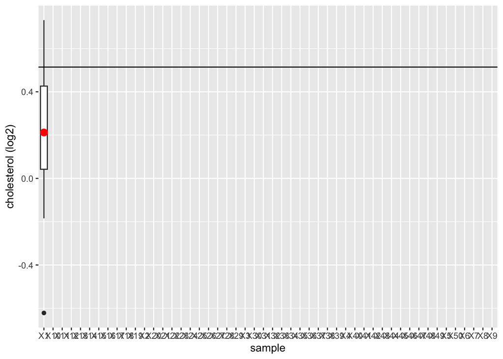

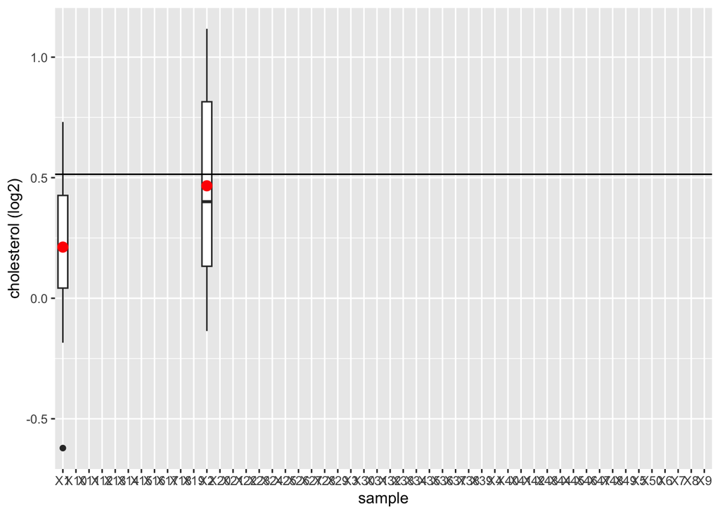

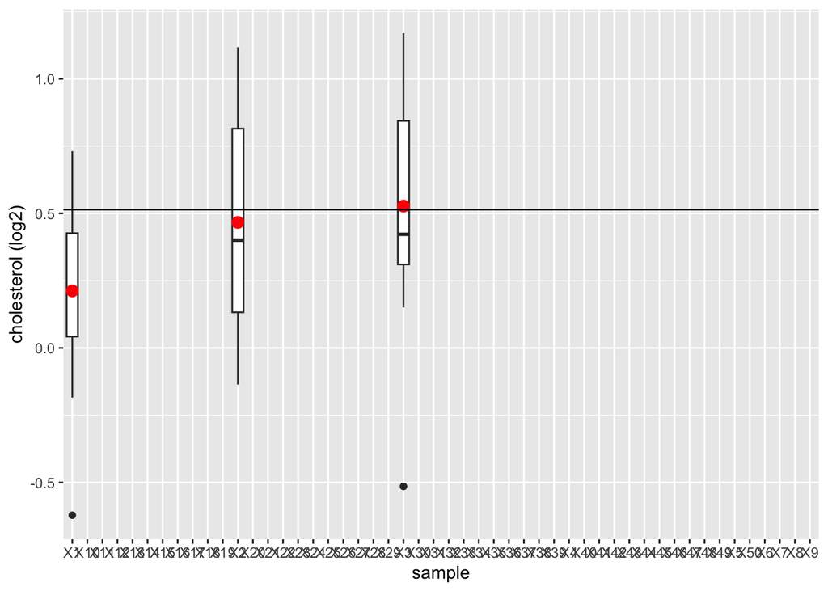

```r
library(NHANES)

fem <- NHANES |>
  dplyr::filter(Gender=="female" & !is.na(DirectChol)) |>
  dplyr::select("DirectChol")

n <- 15 # number of subjects per sample
nSim <- 50 # number of simulations

femSamp <- matrix(nrow=n,ncol=nSim)
set.seed(2105)
for (j in 1:nSim)
{
  femSamp[,j] <- sample(fem$DirectChol,n)
  if (j<4) {
    p <- femSamp |>
      log2() |>
      data.frame() |>
      gather("sample","log2cholesterol") |>
      ggplot(aes(x=sample,y=log2cholesterol)) +
      geom_boxplot() +
      stat_summary(
        fun.y=mean,
        geom="point",
        shape=19,
        size=3,
        color="red",
        fill="red") +
      geom_hline(yintercept = mean(fem$DirectChol |> log2())) +
      ylab("cholesterol (log2)")
    print(p)
  }
}
```

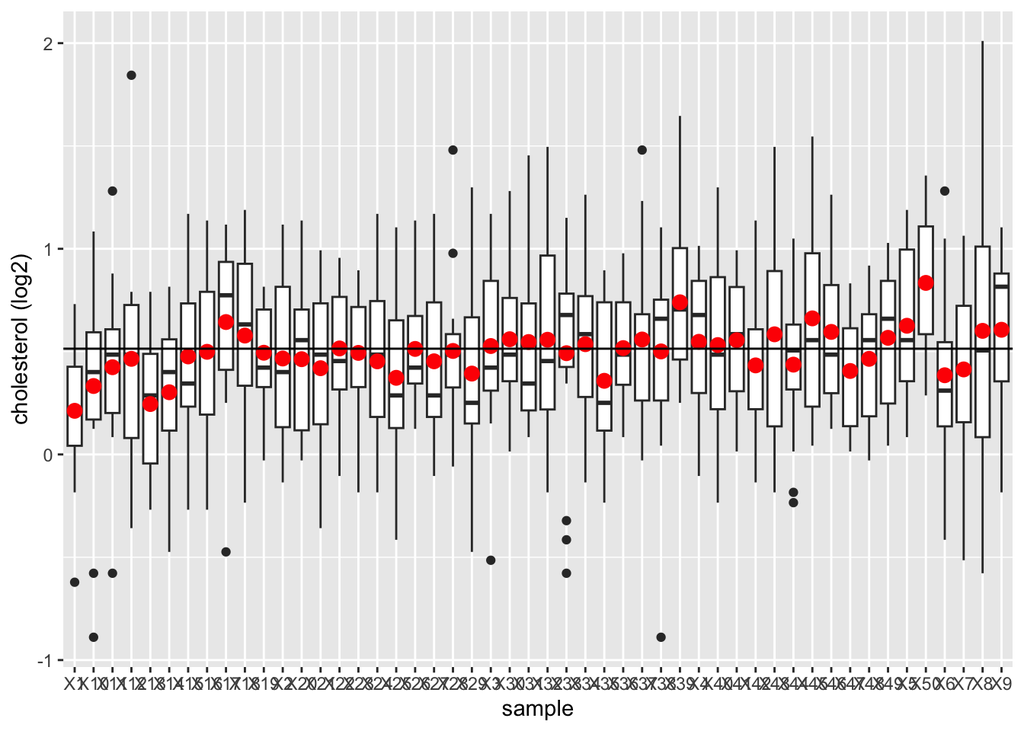

```r
femSamp |>
  log2() |>
  data.frame() |>
  gather("sample","log2cholesterol") |>
  ggplot(aes(x=sample,y=log2cholesterol)) +
  geom_boxplot() +
  stat_summary(fun.y=mean, geom="point", shape=19, size=3, color="red", fill="red") +
  geom_hline(yintercept = mean(fem$DirectChol |> log2())) +
  ylab("cholesterol (log2)")
```

We observeren dat het steekproefgemiddelde fluctueert rond het gemiddelde van de populatie.

Opdracht:

1. Kopieer de code
2. Vergroot de steekproefgrootte tot 100 proefpersonen
3. Wat observeer je?

**Hoe doen we dit op basis van een enkele steekproef?**

- Inzicht in hoe dicht we $\bar X$ tot$\mu$ kunnen verwachten?
- Hoe varieert $\bar X$ van steekproef tot steekproef?
- Variabiliteit op $\bar X$
- Dit moeten we bepalen op basis van een enkele steekproef!
- We moeten assumpties maken
- We nemen aan dat de willekeurige variabelen $X_1, X_2, ..., X_n$ afkomstig zijn van $n$ *onafhankelijke* personen.
- Voor de Captopril studie hebben we afhankelijke observaties
  - Bloeddrukmetingen voor ($Y_{i,before}$) en na ($Y_{i,after}$) toediening van captopril aan dezelfde patiënt $i=1,\ldots,n$.
  - We hebben ze omgezet in n onafhankelijke metingen door het verschil $Y_{i,na}-Y_{i,voor}$ te nemen.

### 3.3.1 Variantie schatter voor $\bar X$

$$\sigma^2_{\bar X}=\frac{\sigma^2}{n}$$

- De standaarddeviatie van $\bar X$ rond $\mu$ is $\sqrt{n}$ keer kleiner dan de deviatie rond de originele observaties $X$.
- Hoe meer observaties we hebben, des te nauwkeuriger $\bar X$.

**Klik om het bewijs te zien**

$$\begin{eqnarray*}
\text{Var}(\bar X)&=&\text{Var} \left(\frac{X_1+ X_2+ ... + X_n}{n}\right) \\
&\overset{*}{=} & \frac{\text{Var}(X_1)+ \text{Var}(X_2)+ ... + \text{Var}(X_n)}{n^2} \\
&=& \frac{\sigma^2 + \sigma^2 + ... \sigma^2}{n^2} \\
&= & \frac{\sigma^2}{n}.
\end{eqnarray*}$$

- (*) Dit is gebaseerd op de assumptie van onafhankelijkheid
  $$\text{Var}[a X_1 + b X_2] = a^2\text{Var}[X_1] + b^2 \text{Var}[X_2] + 2 ab\text{Covar}[X_1,X_2]$$
  - Met $Covar[X_1,X_2]=0$ wanneer $X_1$ en $X_2$ onafhankelijk zijn.

**Definitie: standaard error**

De standaard deviatie van $\bar{X}$ is $\sigma/\sqrt{n}$ en wordt ook wel de **standaard error** van het gemiddelde genoemd. Over het algemeen verwijst men naar de standaarddeviatie van een schatter voor een bepaalde parameter $\theta$ met de term **standaard error** van de schatter die wordt aangeduid als $SE$

### 3.3.2 Captopril voorbeeld

- $n = 15$ verschillen in systolische bloeddruk
- Stel dat de standaarddeviatie van de bloeddrukverschillen in de populatie $\sigma = 9.0$ mmHg is
- Dan wordt de standaard error (SE) op de gemiddelde systolische bloeddruk verschillen $\bar X$:

$$SE = \frac{9.0}{\sqrt{15}}=2.32\text{mmHg.}$$

- Over het algemeen zijn $\sigma$, en dus de SE op het steekproefgemiddelde onbekend.
- We moeten dus ook de standaarddeviatie van de steekproef schatten om de standaard error te verkrijgen.
- Schatter: $SE=S/\sqrt{n},$
- Met $S^2$ de steekproefvariantie van $X_1,...,X_n$ en $S$ de steekproefstandaarddeviatie
- Voor het Captopril voorbeeld krijgen we:

```r
n <- length(captopril$deltaSBP)
se <- sd(captopril$deltaSBP)/sqrt(n)
se
```

```
[1] 2.330883
```

### 3.3.3 standaarddeviatie vs standaard error

#### 3.3.3.1 Illustratie via herhaalde steekproeven

- Verschillende steekproef groottes: 10, 50, 100
- Neem 1000 steekproeven per steekproef grootte van de NHANES studie, voor iedere steekproef berekenen we:
  - Het gemiddelde
  - De steekproefstandaarddeviatie
  - de standaard error
- We maken een boxplot van de steekproefstandaardevaties en de standaard errors voor de verschillende steekproefgroottes
- In plaats van een for loop te gebruiken zullen we de sapply functie gebruiken die efficiënter is. Het neemt een vector of lijst als invoer en past de functie toe op ieder element van de vector of lijst.

```r
set.seed(24)
femSamp10 <- sapply(
  1:1000,
  function(j,x,size) sample(x,size),
  size=10,
  x=fem$DirectChol)

femSamp50 <- sapply(
  1:1000,
  function(j,x,size) sample(x,size),
  size=50,
  x=fem$DirectChol)

femSamp100 <- sapply(
  1:1000,
  function(j,x,size) sample(x,size),
  size=100,
  x=fem$DirectChol)

res<-rbind(
  femSamp10 |>
    log2()|>
    as.data.frame() |>
    gather(sample,log2Chol) |>
    group_by(sample)|>
    summarize_at("log2Chol",
               list(median=~median(.,na.rm=TRUE),
                    mean=~mean(.,na.rm=TRUE),
                    sd=~sd(.,na.rm=TRUE),
                    n=function(x) sum(!is.na(x)))) |>
    mutate(se=sd/sqrt(n)) ,
  femSamp50 |>
    log2() |>
    as.data.frame() |>
    gather(sample,log2Chol) |>
    group_by(sample)|>
    summarize_at("log2Chol",
               list(median=~median(.,na.rm=TRUE),
                    mean=~mean(.,na.rm=TRUE),
                    sd=~sd(.,na.rm=TRUE),
                    n=function(x) sum(!is.na(x)))) |>
    mutate(se=sd/sqrt(n)),
  femSamp100 |>
    log2() |>
    as.data.frame() |>
    gather(sample,log2Chol) |>
    group_by(sample)|>
    summarize_at("log2Chol",
               list(median=~median(.,na.rm=TRUE),
                    mean=~mean(.,na.rm=TRUE),
                    sd=~sd(.,na.rm=TRUE),
                    n=function(x) sum(!is.na(x)))) |>
    mutate(se=sd/sqrt(n))
  )
```

**Gemiddelden**

We illustreren de impact van steekproefgrootte op de distributie van de gemiddeldes van verschillende steekproeven

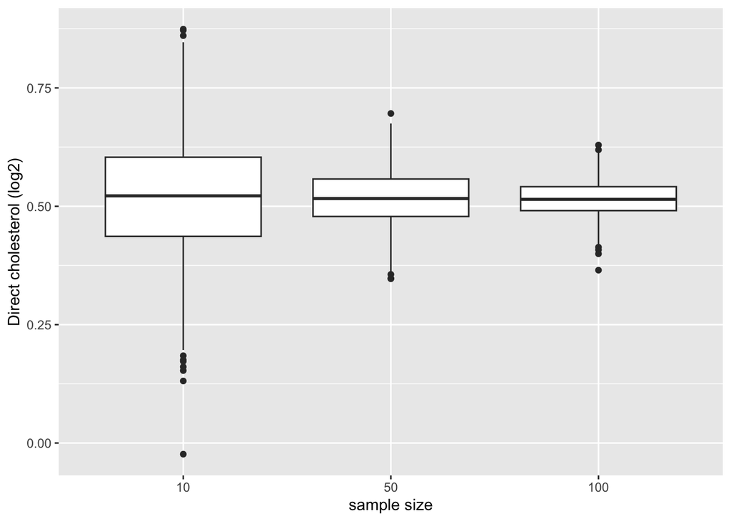

```r
res |>
  ggplot(aes(x= n |> as.factor(),y = mean)) +
  geom_boxplot() +
  ylab("Direct cholesterol (log2)") +
  xlab("sample size")
```

- Merk op dat de variatie van de steekproefgemiddelden inderdaad afneemt naarmate de steekproefgrootte toeneemt. De schatting wordt dus nauwkeuriger naarmate de steekproefgrootte toeneemt.

**Standard deviatie**

We illustreren nu de impact van de steekproefgrootte op de verdeling van de standaarddeviatie van de verschillende steekproeven

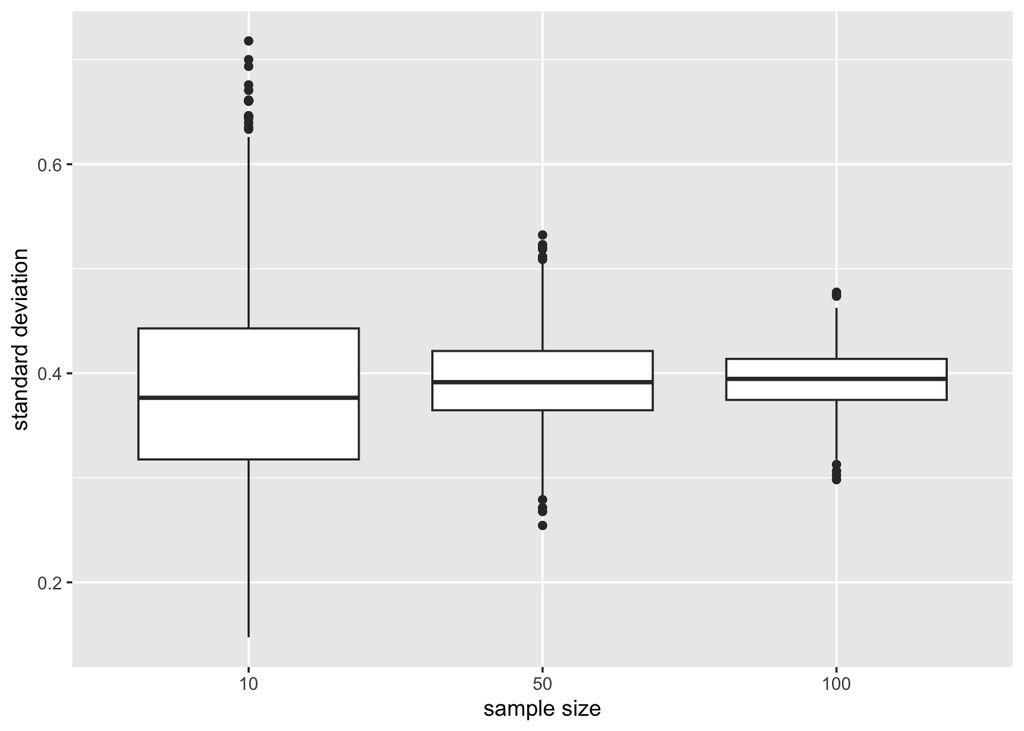

```r
res |>
  ggplot(aes(x=n|>as.factor(),y=sd)) +
  geom_boxplot() +
  ylab("standard deviation") +
  xlab("sample size")
```

- De standaarddeviatie blijft vergelijkbaar voor de steekproefgroottes. Het is gecentreerd rond dezelfde waarde: de standaarddeviatie in de populatie. Het vergroten van de steekproefgrootte heeft inderdaad geen invloed op de variabiliteit in de populatie!
- Opnieuw zien we dat de variabiliteit van de standaarddeviatie afneemt naarmate de steekproefgrootte toeneemt. De standaarddeviatie kan dus ook nauwkeuriger worden geschat naarmate de steekproefgrootte toeneemt.

**Standaard error van het gemiddelde**

Ten slotte illustreren we de impact van de steekproefgrootte op de verdeling van de standaarddeviatie van het gemiddelde van de verschillende steekproeven, de standaard error.

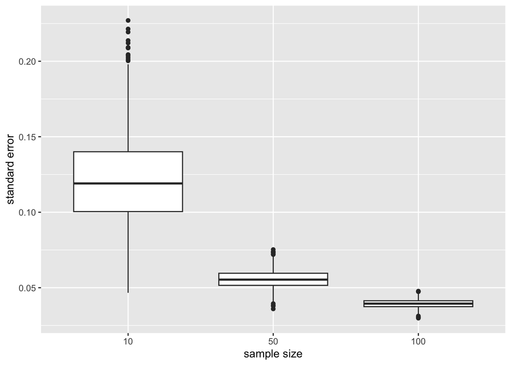

```r
res |>
ggplot(aes(x=n|>as.factor(),y=se)) +
geom_boxplot() +
ylab("standard error") +
xlab("sample size")
```

- De standaard error (de schatter voor de nauwkeurigheid van het steekproefgemiddelde) vermindert aanzienlijk naarmate de steekproefgrootte toeneemt, wat opnieuw bevestigt dat de schatting van het steekproefgemiddelde nauwkeuriger wordt.

### 3.3.4 Normaal verdeelde data

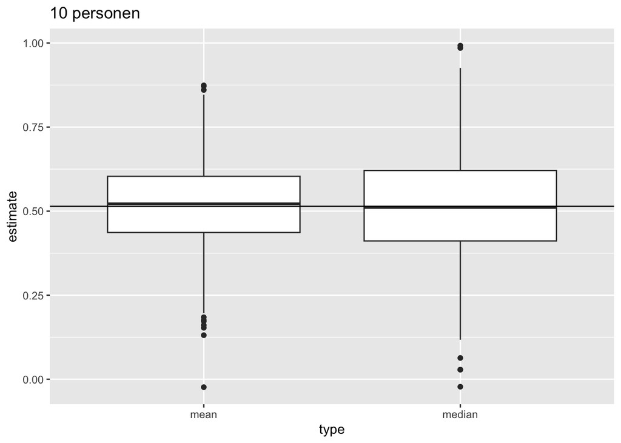

```r
res |>
  filter(n == 10) |>
  select(mean,median) |>
  gather(type,estimate) |>
  ggplot(aes(x = type,y = estimate)) +
  geom_boxplot() +
  geom_hline(yintercept = fem$DirectChol |>
    log2() |>
    mean()) +
  ggtitle("10 personen")
```

Vervolgens vergelijken we de verdeling van het gemiddelde en de mediaan in herhaalde steekproeven van steekproefgrootte 50.

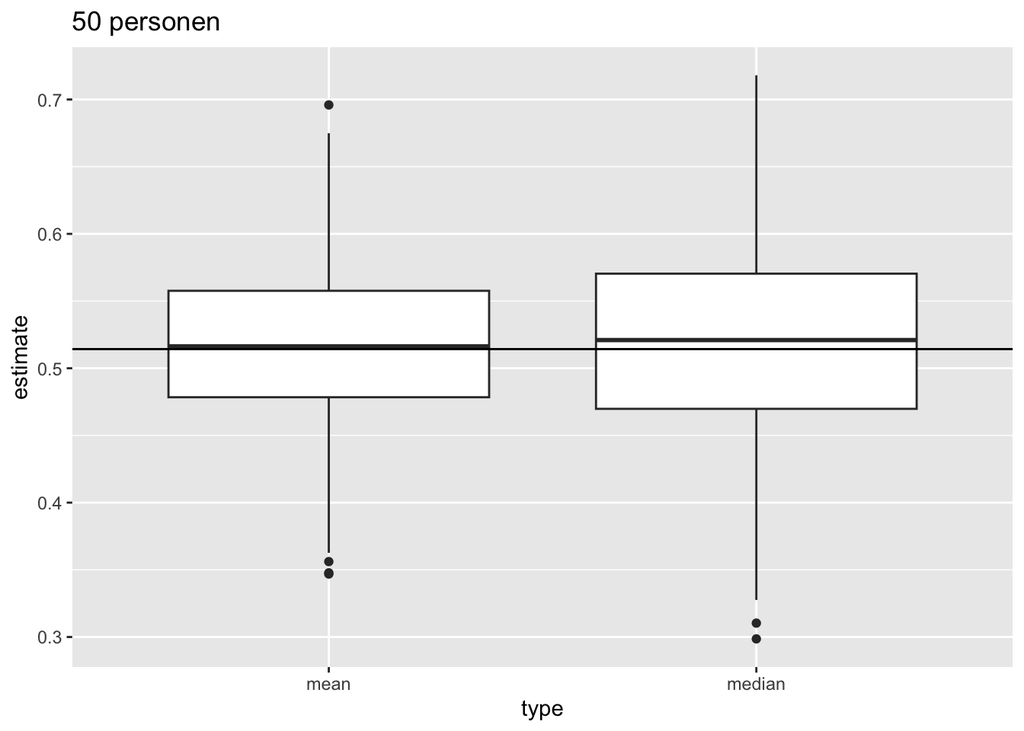

```r
res |>
  filter(n == 50) |>
  select(mean, median) |>
  gather(type, estimate) |>
  ggplot(aes(x = type,y = estimate)) +
  geom_boxplot()+
  geom_hline(yintercept = fem$DirectChol |>
    log2() |>
    mean()) +
  ggtitle("50 personen")
```

## 3.4 Verdeling van het steekproefgemiddelde

- Hoe varieert $\bar X$ van steekproef tot steekproef?
- Verdeling van $\bar X$?
- Als $\bar X$ normaal verdeeld is, heeft de standaard error een goede interpretatie: de SE is de standaard deviatie van het steekproefgemiddelde.
- Als de data $X_i$ normaal verdeeld zijn, is het steekproefgemiddelde ook normaal verdeeld.

$$X_i \sim N(\mu,\sigma^2) \rightarrow \bar X \sim N(\mu, \sigma^2/n)$$

### 3.4.1 NHANES: cholesterol

We illustreren dit nogmaals met een simulatie gebruik makende van de NHANES-studie. De log2-cholesterolwaarden zijn normaal verdeeld.

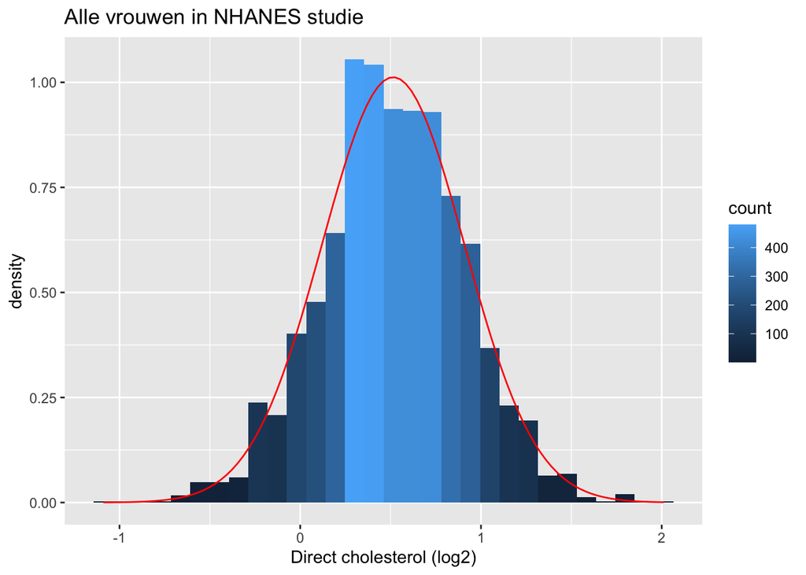

```r
 fem |>
  ggplot(aes(x = DirectChol |> log2()))+
  geom_histogram(aes(y = ..density.., fill = ..count..)) +
  xlab("Direct cholesterol (log2)") +
  stat_function(
    fun = dnorm,
    color = "red",
    args = list(
      mean=mean(fem$DirectChol|>log2()),
      sd = sd(fem$DirectChol|>log2())
      )
    ) +
  ggtitle("Alle vrouwen in NHANES studie")
```

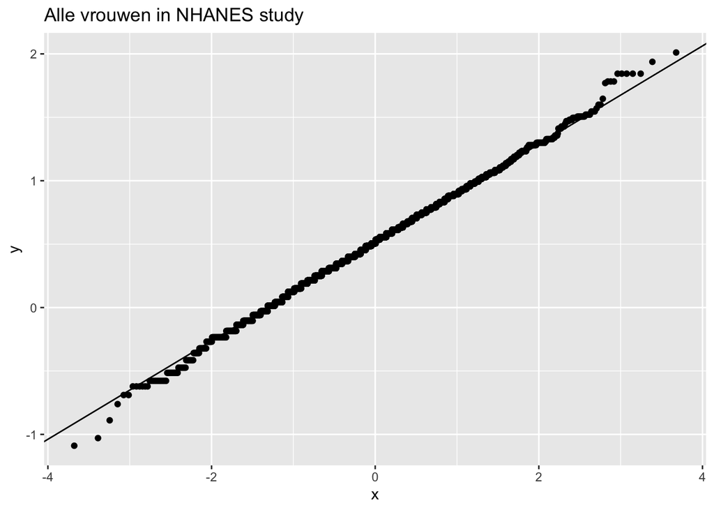

```r
fem |>
  ggplot(aes(sample = DirectChol |> log2())) +
  stat_qq() +
  stat_qq_line() +
  ggtitle("Alle vrouwen in NHANES study")
```

##### 3.4.1.0.1 Evalueer de verdeling van het gemiddelde voor steekproeven van grootte 10

We onderzoeken de resultaten voor de steekproefgrootte van 10.

We bekijken eerst de plot voor de eerste steekproef.

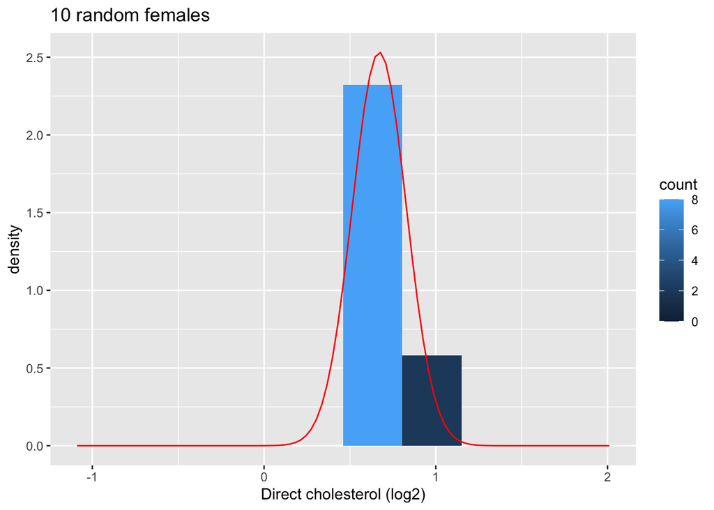

```r
log2Chol <- femSamp10[,1] |>
  log2()
data.frame(log2Chol) |>
  ggplot(aes(x=log2Chol))+
    geom_histogram(aes(y=..density.., fill=..count..),bins=10) +
    xlab("Direct cholesterol (log2)") +
    stat_function(
      fun=dnorm,
      color="red",
      args=list(
        mean=femSamp10[,1]|>log2()|>mean(), sd=femSamp10[,1]|>log2()|>sd())
      ) +
    ggtitle("10 random females") +
    xlim(fem$DirectChol |> log2() |> range())
```

Vervolgens kijken we naar de verdeling van het steekproefgemiddelde over 1000 steekproeven van steekproefgrootte 10.

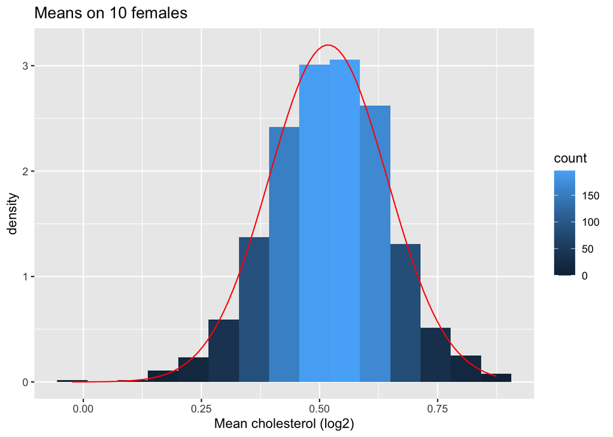

```r
meanLog2Chol <- femSamp10 |>
  log2() |>
  colMeans()
data.frame(meanLog2Chol) |>
  ggplot(aes(x=meanLog2Chol)) +
  geom_histogram(aes(y=..density.., fill=..count..),bins=15) +
  xlab("Mean cholesterol (log2)") +
  stat_function(
    fun=dnorm,
    color="red",
    args=list(
      mean=femSamp10|>log2()|> colMeans() |> mean(),
      sd=femSamp10|>log2()|> colMeans() |> sd())
    ) +
  ggtitle("Means on 10 females")
```

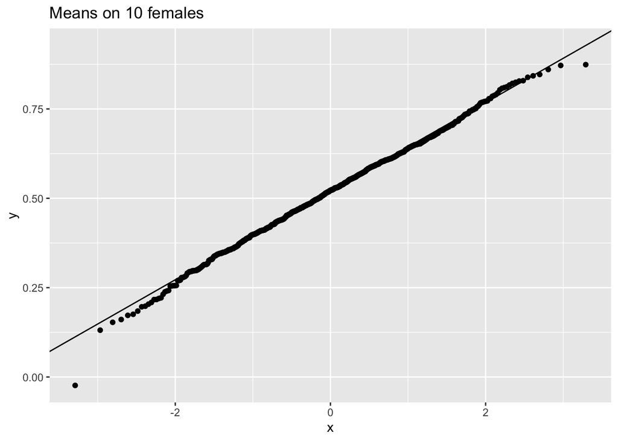

```r
meanLog2Chol <- femSamp10 |>
  log2()|>
  colMeans()
data.frame(meanLog2Chol) |>
  ggplot(aes(sample=meanLog2Chol)) +
  stat_qq() +
  stat_qq_line() +
  ggtitle("Means on 10 females")
```

**We hebben dus bevestigd dat het gemiddelde ongeveer normaal verdeeld is voor studies met 10 vrouwen, terwijl de originele gegevens ongeveer normaal verdeeld zijn.**

#### 3.4.1.1 Captopril studie

- De systolische bloeddrukverschillen in de Captopril studie zijn bij benadering normaal verdeeld.
- s.e.= 2.32 mm Hg
- In 95 van de 100 studies met n = 15 proefpersonen verwachten we dat het steekproefgemiddelde van de systolische bloeddrukverschillen ($\bar X$) op minder dan $2 \times 2.32 = 4.64$mm Hg van het werkelijk populatiegemiddelde van de bloeddrukverschillen geschat wordt.

### 3.4.2 Niet-normaal verdeelde data

- Als individuele observaties geen normale verdeling hebben, is $\bar X$ nog steeds normaal verdeeld wanneer het aantal observaties groot genoeg is.
- Hoe groot moet de steekproef zijn om de normale benadering te laten werken?
- Dit hangt af van de scheefheid van de distributie!

#### 3.4.2.1 NHANES: cholesterol

- We kunnen dit evalueren in de NHanes-studie als we de gegevens niet log2 transformeren.

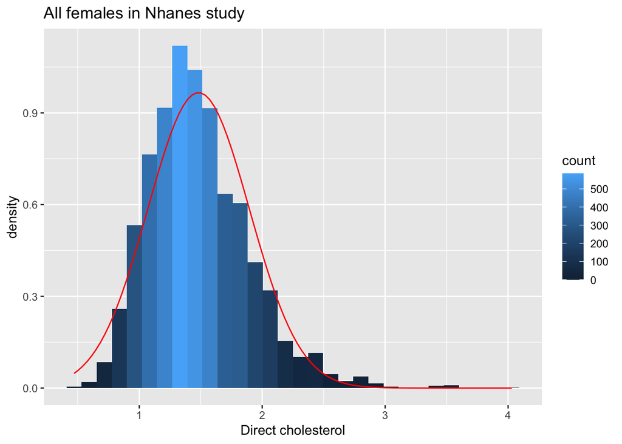

```r
fem |>
   ggplot(aes(x=DirectChol))+
   geom_histogram(aes(y=..density.., fill=..count..)) +
   xlab("Direct cholesterol") +
   stat_function(
     fun=dnorm,
     color="red",
     args=list(
       mean=mean(fem$DirectChol),
       sd=sd(fem$DirectChol))
    ) +
   ggtitle("All females in Nhanes study")
```

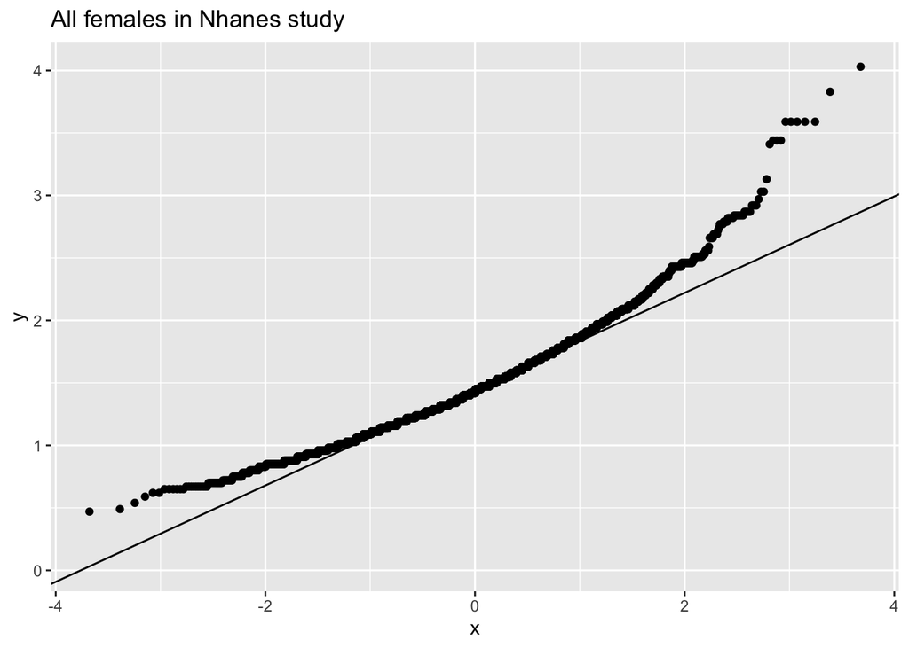

```r
 fem |>
  ggplot(aes(sample=DirectChol)) +
  stat_qq() +
  stat_qq_line() +
  ggtitle("All females in Nhanes study")
```

De cholesterol data zijn duidelijk niet-normaal verdeeld.

##### 3.4.2.1.1 Verdeling van het steekproefgemiddelde voor verschillende steekproefgroottes

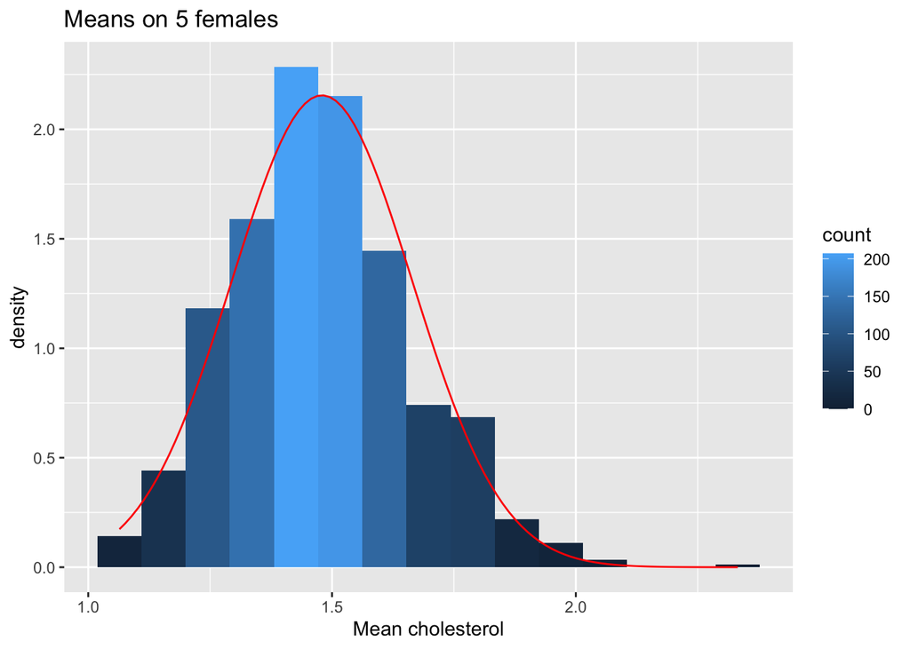

```r
set.seed(121)
femSamp5 <- sapply(
  1:1000,
  function(j,x,size) sample(x,size),
  size = 5,
  x = fem$DirectChol)

meanChol <- femSamp5 |>
  colMeans()
data.frame(meanChol) |> ggplot(aes(x=meanChol)) +
  geom_histogram(aes(y=..density.., fill=..count..),bins=15) +
  xlab("Mean cholesterol") +
  stat_function(
    fun=dnorm,
    color="red",
    args=list(
      mean=femSamp5|> colMeans() |> mean(),
      sd=femSamp5|> colMeans() |> sd())
    ) +
  ggtitle("Means on 5 females")
```

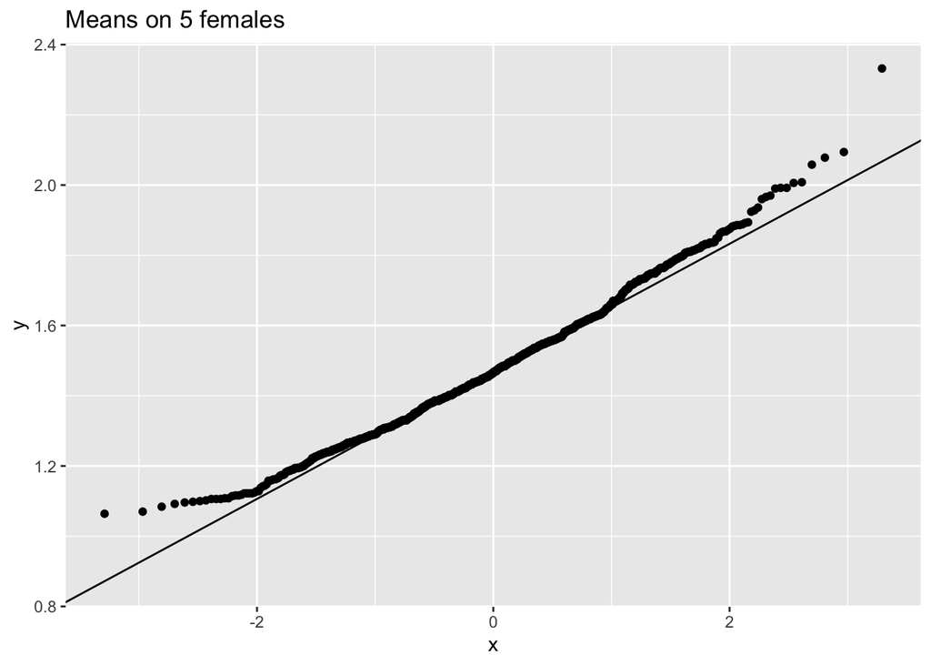

```r
meanChol <- femSamp5 |>
  colMeans()
data.frame(meanChol) |>
  ggplot(aes(sample=meanChol)) +
  stat_qq() +
  stat_qq_line() +
  ggtitle("Means on 5 females")
```

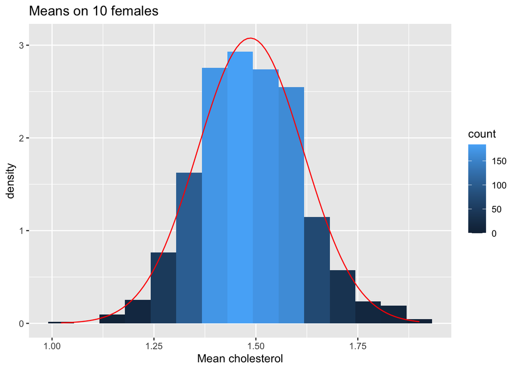

```r
meanChol <- femSamp10 |>
  colMeans()
data.frame(meanChol) |> ggplot(aes(x=meanChol)) +
  geom_histogram(aes(y=..density.., fill=..count..),bins=15) +
  xlab("Mean cholesterol") +
  stat_function(
    fun=dnorm,
    color="red",
    args=list(
      mean=femSamp10|> colMeans() |> mean(),
      sd=femSamp10|> colMeans() |> sd())
    ) +
ggtitle("Means on 10 females")
```

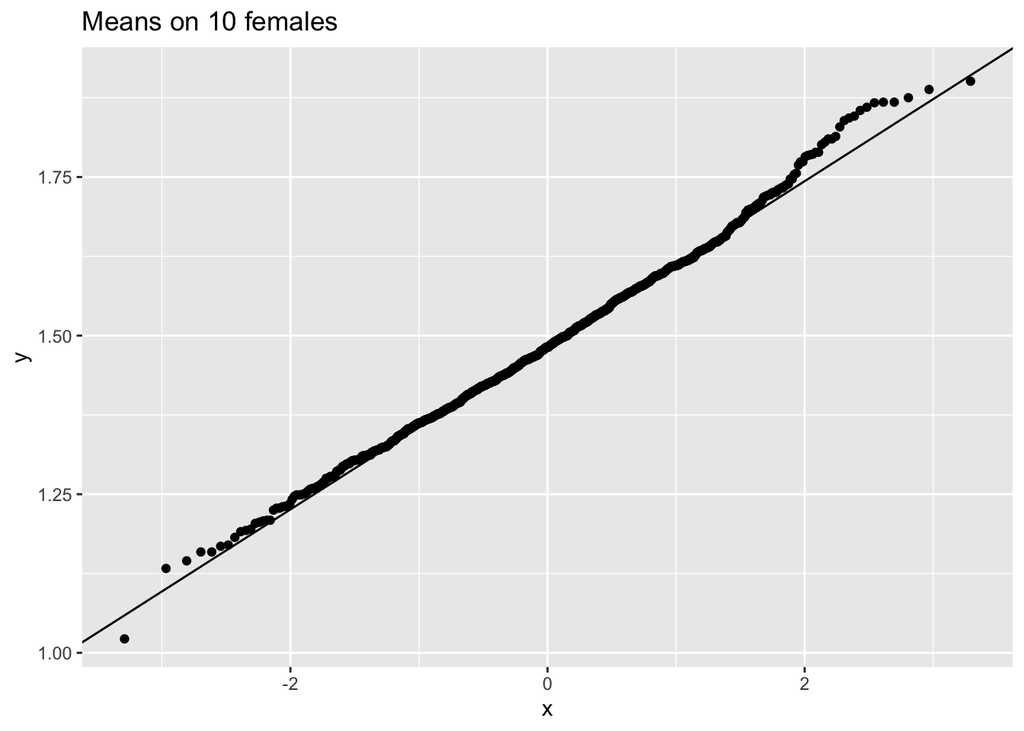

```r
meanChol <- femSamp10 |>
  colMeans()
data.frame(meanChol) |>
  ggplot(aes(sample=meanChol)) +
  stat_qq() +
  stat_qq_line() +
  ggtitle("Means on 10 females")
```

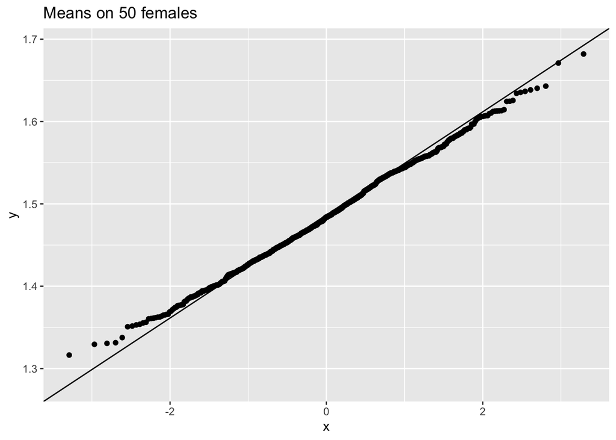

```r
meanChol <- femSamp50 |>
  colMeans()
data.frame(meanChol) |>
  ggplot(aes(sample=meanChol)) +
  stat_qq() +
  stat_qq_line() +
  ggtitle("Means on 50 females")
```

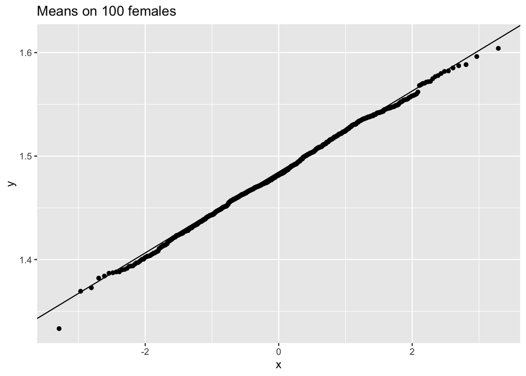

```r
meanChol <- femSamp100 |>
  colMeans()
data.frame(meanChol) |>
  ggplot(aes(sample=meanChol)) +
  stat_qq() +
  stat_qq_line() +
  ggtitle("Means on 100 females")
```

- **We merken op dat wanneer de data niet normaal verdeeld zijn, de verdeling van het steekproefgemiddelde niet normaal verdeeld is over kleine steekproeven**
- **Voor grote steekproeven is het steekproefgemiddelde van niet-normale gegevens echter nog steeds ongeveer normaal verdeeld.**

### 3.4.3 Centrale limietstelling

Laat $X_1, \ldots, X_n$ een reeks willekeurige variabelen zijn die onafhankelijk van dezelfde verdeling (populatie) worden getrokken. Zolang de steekproefgrootte n voldoende groot is, is het steekproefgemiddelde $\bar X$ ongeveer normaal verdeeld, ongeacht de verdeling van de waarnemingen $X_i$.

### 3.4.4 Overzicht van de verdeling van het gemiddelde

[figure not shown]

# 4 Interval schatters

- $\bar X$ varieert rond $\mu$
- hier zullen we een interval ontwikkelen rond $\bar X$ dat de waarde $\mu$ bevat met een waarschijnlijkheid van 95% voor een willekeurige steekproef.
- We nemen eerst aan dat $\sigma^2$ bekend is en we zullen deze aanname later versoepelen.

## 4.1 Normaal verdeelde data met gekende variantie

- $X\sim N(\mu,\sigma^2) \rightarrow \bar X\sim N\left(\mu,\frac{\sigma^2}{n}\right)$
- 95% referentie-interval voor het steekproefgemiddelde

$$\begin{equation*}
\left[\mu - 1.96 \frac{\sigma}{\sqrt{n}},\mu + 1.96 \frac{\sigma}{\sqrt{n}}%
\right]
\end{equation*}$$

- Het interval bevat het steekproefgemiddelde van een willekeurige steekproef met een kans van 95%.
- We kunnen dit niet berekenen aangezien $\mu$ niet gekend is.
- Schat $\mu$ met $\bar X$.
  $$\begin{equation*}
  \left[\bar X - 1.96 \frac{\sigma}{\sqrt{n}},\bar X + 1.96 \frac{\sigma}{\sqrt{n}}\right]
  \end{equation*}$$
- Meer bruikbare interpretatie:
- herschrijf $\mu - 1.96 \ \sigma/\sqrt{n} < \bar{X}$ as $\mu < \bar{X} + 1.96 \ \sigma/\sqrt{n}$.

Zodat we kunnen schrijven
$$\begin{eqnarray*}
95\% &=& P( \mu - 1.96 \ \sigma/\sqrt{n} < \bar{X} < \mu + 1.96 \ \sigma/\sqrt{n} ) \\
&=&P( \bar{X} - 1.96 \ \sigma/\sqrt{n} < \mu < \bar{X} + 1.96 \ \sigma/\sqrt{n} )
\end{eqnarray*}$$

**Definitie van 95% betrouwbaarheids interval op het gemiddelde** Voor een willekeurige steekproef bevat het interval
$$\begin{equation}
[\bar{X} - 1.96 \ \sigma/\sqrt{n} , \bar{X} + 1.96 \ \sigma/\sqrt{n} ],
\end{equation}$$
het populatiegemiddelde $\mu$ met een kans van 95%.

- De kans dat het BI voor een willekeurige steekproef de populatieparameter $\mu$ bevat, dus 95%, wordt ook wel het **betrouwbaarheidsniveau** genoemd.
- Merk op dat de onder- en bovengrens van het interval ook willekeurige variabelen zijn die van steekproef tot steekproef variëren. Verschillende steekproeven resulteren inderdaad in verschillende betrouwbaarheidsintervallen omdat ze gebaseerd zijn op verschillende waarnemingen.
- Het zijn dus *stochastische intervallen*
- 95% van de steekproeven zullen een 95% betrouwbaarheidsinterval produceren dat het populatiegemiddelde $\mu$ zal bevatten. De overige 5% zullen intervallen produceren die het populatiegemiddelde niet bevatten.
- Op basis van één interval kun je niet concluderen dat het de werkelijke populatieparameter bevat, omdat de waarde ervan onbekend is.

Over het algemeen is de standaarddeviatie ongekend en moet het geschat worden.

- Voor grote $n$, zal $[\bar{X} - 1.96 \ s/\sqrt{n} , \bar{X} + 1.96 \ s/\sqrt{n} ]$ het populatiegemiddelde bevatten met een probabiliteit van 95%.

### 4.1.1 NHANES log2 cholesterol voorbeeld

#### 4.1.1.1 1 steekproef

```r
set.seed(3146)
samp50 <- sample(fem$DirectChol,50)

ll <- mean(samp50 |> log2()) - 1.96*sd(samp50 |> log2())/sqrt(50)
ul <- mean(samp50 |> log2()) + 1.96*sd(samp50 |> log2())/sqrt(50)
popMean <- mean(fem$DirectChol|>log2())

c(ll=ll,ul=ul,popMean=popMean)
```

```
       ll        ul   popMean
0.4326245 0.6291622 0.5142563
```

#### 4.1.1.2 Herhaalde steekproeven

```r
res$ll <- res$mean-1.96*res$se
res$ul <- res$mean+1.96*res$se
mu <- fem$DirectChol|>
  log2()|>
  mean()

res$inside<- res$ll <= mu & mu <= res$ul
res$n <- as.factor(res$n)
res |>
  group_by(n) |>
  summarize(coverage=mean(inside)) |>
  spread(n,coverage)
```

```
# A tibble: 1 × 3
   `10`  `50` `100`
  <dbl> <dbl> <dbl>
1  0.92 0.942 0.954
```

- Merk op dat de omvang in de steekproeven met 10 waarnemingen te laag is omdat we geen rekening houden met de onzekerheid in de schatting van de standaarddeviatie.
- Als we kijken naar de eerste 20 intervallen, bevat 1 van de 20 niet het populatiegemiddelde.

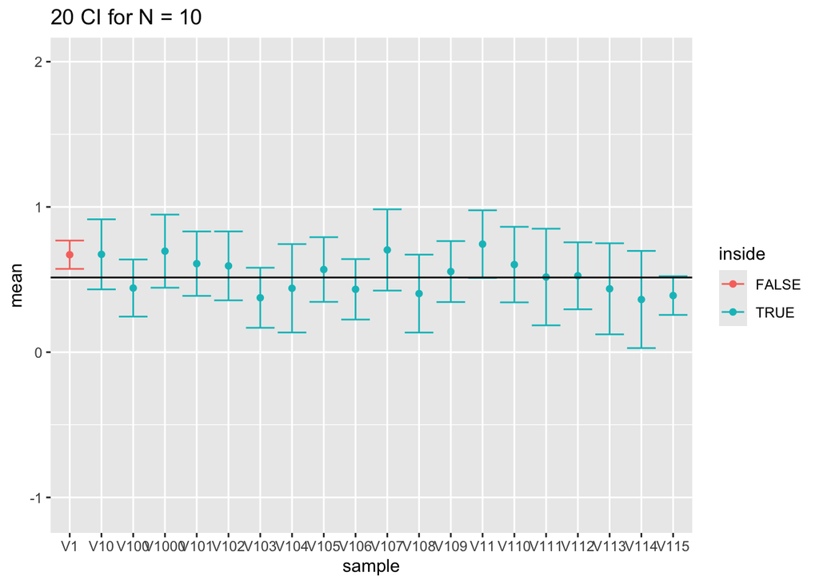

```r
res |>
  filter(n==10) |>
  slice(1:20) |>
  ggplot(aes(x = sample,y = mean,color = inside)) +
  geom_point() +
  geom_errorbar(aes(ymin = mean-1.96*se,ymax = mean+1.96*se))+
  geom_hline(yintercept = fem$DirectChol |> log2() |> mean()) +
  ggtitle("20 CI for N = 10") +
  ylim(range(fem$DirectChol |> log2()))
```

- Voor grote steekproeven (100) is de omvang prima omdat we de standaarddeviatie met een relatief hoge precisie kunnen schatten.

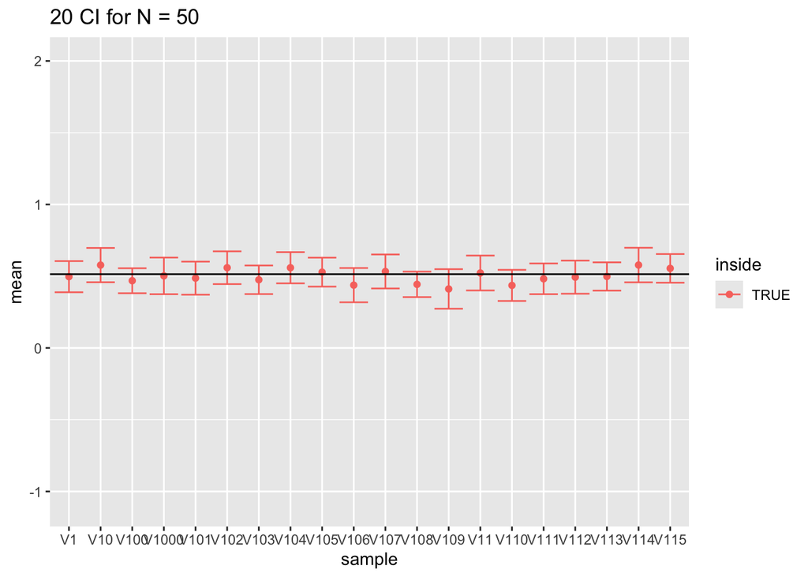

```r
res |>
  filter(n == 50) |>
  slice(1:20) |>
  ggplot(aes(x = sample,y = mean,color = inside)) +
  geom_point() +
  geom_errorbar(aes(ymin = mean-1.96*se,ymax = mean+1.96*se))+
  geom_hline(yintercept = fem$DirectChol |> log2() |> mean()) +
  ggtitle("20 CI for N = 50") +
  ylim(range(fem$DirectChol |> log2()))
```

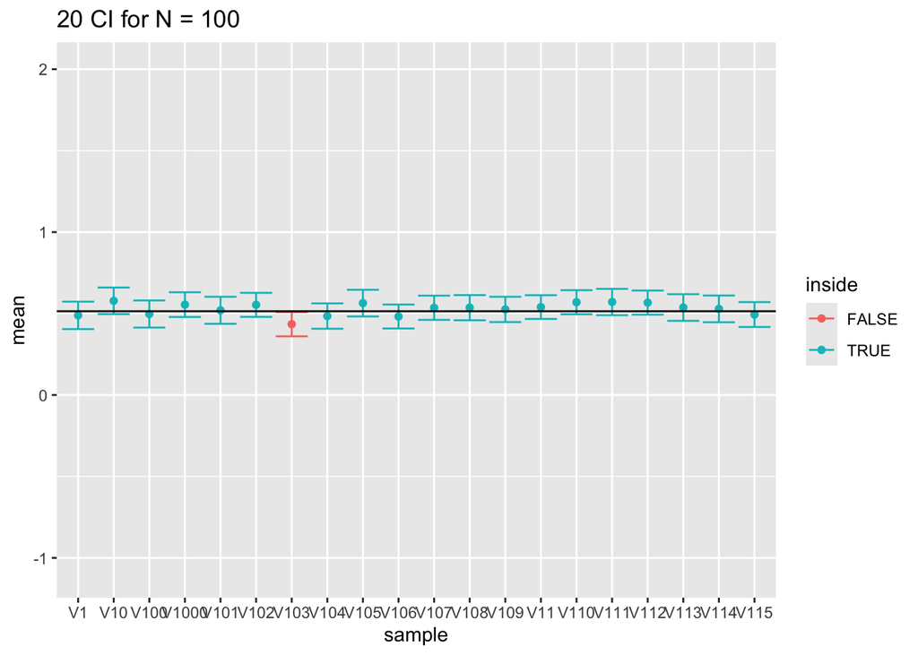

```r
res |>
  filter(n == 100) |>
  slice(1:20) |>
  ggplot(aes(x = sample,y = mean,color = inside)) +
  geom_point() +
  geom_errorbar(aes(ymin = mean-1.96*se,ymax = mean+1.96*se))+
  geom_hline(yintercept = fem$DirectChol |> log2() |> mean()) +
  ggtitle("20 CI for N = 100") +
  ylim(range(fem$DirectChol |> log2()))
```

- Wat heb je geobserveerd voor de intervalbreedte?

### 4.1.2 Andere betrouwbaarheidsniveaus

- We kunnen $z_{2.5\%}=1.96$ vervangen door een ander kwantiel van de normale verdeling $z_{\alpha/2}$ om een interval te krijgen met een ander betrouwbaarheidsniveau $1-\alpha$.
- Betrouwbaarheidsintervallen worden niet alleen gebruikt voor het gemiddelde, maar ook voor andere populatieparameters.